# Assignment 3 - Spatial Relationships

## Map 6 - Overlap of Open Space and the Neighborhoods

```r
Neighborhood <- Neighborhood %>%
  mutate(num_OpenS = lengths(st_overlaps(Neighborhood, OpenS))) %>%
  mutate(has_OpenS = num_OpenS > 0)

n_OpenS_Neighborhood <- sum(Neighborhood$has_OpenS)

n_OpenS_Neighborhood
```

```
## [1] 11
```

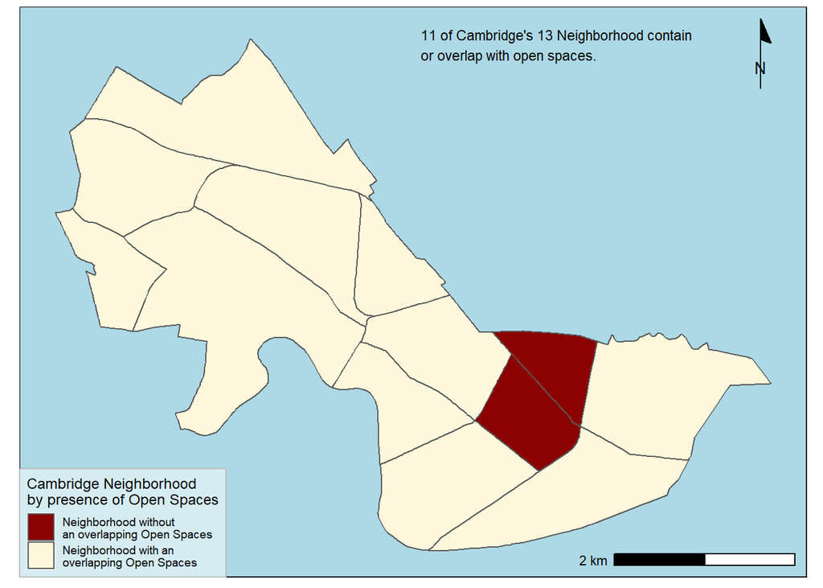

```r
left_side  <- st_bbox(OpenS)$xmin
top_side <- st_bbox(OpenS)$ymax

ggplot(OpenS) +
  geom_sf(fill = "lightblue", color = NA) +
  geom_sf(data = Neighborhood,
          aes(fill = has_OpenS)) +
  scale_fill_manual(values = c("darkred", "cornsilk1"),
          name = "Cambridge Neighborhood\nby presence of Open Spaces",
          labels = c("Neighborhood without\nan overlapping Open Spaces",
                     "Neighborhood with an\noverlapping Open Spaces")) +
  annotation_scale(location = "br") +
  annotation_north_arrow(location = "tr",
                         style = north_arrow_minimal()) +
  annotate(geom = "text", x = left_side + 4000,
           y = top_side - 300,
           label = paste(n_OpenS_Neighborhood ,
                         "of Cambridge's",
                         length(Neighborhood$Name),
                         "Neighborhood contain\nor overlap with",
                         "open spaces."),
           hjust = 0, vjust = 0, size = 3) +
  theme_map() +
  theme(panel.background = element_rect(fill = "lightblue"),
        legend.background = element_rect(fill = alpha("white", 0.5),
                                         color = "gray"))
```

## Contribution Statement

We found the dataset together, as a team from the Cambridge Open Data portal. Each member then used the data set consisting of 2 point layers and 2 polygon layers and then contributed 2 maps each for the final submission. We have decided that each team member gets 10 points. We were all engaged in the project and all met in person to start the maps and communicated throughout the process to complete the assignment.